# Risk Factor Analysis

## Outcome Variable

**Outcome Variable:** ever_stunted

## Predictor Variables

**Intervention Variable:** pers_wast

**Adjustment Set:**

- arm
- brthmon
- W_mage
- meducyrs
- hhwealth_quart
- month
- W_parity
- delta_W_mage
- delta_meducyrs
- delta_hhwealth_quart
- delta_month
- delta_W_parity

## Stratifying Variables

The analysis was stratified on these variable(s):

- agecat
- studyid
- country

## Data Summary

| agecat | studyid | country | pers_wast | ever_stunted | n_cell | n |
| --- | --- | --- | --- | --- | --- | --- |
| 0-24 months (no birth st.) | CMC-V-BCS-2002 | INDIA | 0 | 0 | 24 | 292 |
| 0-24 months (no birth st.) | CMC-V-BCS-2002 | INDIA | 0 | 1 | 228 | 292 |
| 0-24 months (no birth st.) | CMC-V-BCS-2002 | INDIA | 1 | 0 | 3 | 292 |
| 0-24 months (no birth st.) | CMC-V-BCS-2002 | INDIA | 1 | 1 | 37 | 292 |
| 0-24 months (no birth st.) | CMIN | BANGLADESH | 0 | 0 | 37 | 166 |
| 0-24 months (no birth st.) | CMIN | BANGLADESH | 0 | 1 | 123 | 166 |
| 0-24 months (no birth st.) | CMIN | BANGLADESH | 1 | 0 | 2 | 166 |
| 0-24 months (no birth st.) | CMIN | BANGLADESH | 1 | 1 | 4 | 166 |
| 0-24 months (no birth st.) | CONTENT | PERU | 0 | 0 | 162 | 195 |
| 0-24 months (no birth st.) | CONTENT | PERU | 0 | 1 | 33 | 195 |
| 0-24 months (no birth st.) | CONTENT | PERU | 1 | 0 | 0 | 195 |
| 0-24 months (no birth st.) | CONTENT | PERU | 1 | 1 | 0 | 195 |
| 0-24 months (no birth st.) | EE | PAKISTAN | 0 | 0 | 41 | 213 |
| 0-24 months (no birth st.) | EE | PAKISTAN | 0 | 1 | 157 | 213 |
| 0-24 months (no birth st.) | EE | PAKISTAN | 1 | 0 | 0 | 213 |
| 0-24 months (no birth st.) | EE | PAKISTAN | 1 | 1 | 15 | 213 |
| 0-24 months (no birth st.) | GMS-Nepal | NEPAL | 0 | 0 | 161 | 492 |
| 0-24 months (no birth st.) | GMS-Nepal | NEPAL | 0 | 1 | 275 | 492 |
| 0-24 months (no birth st.) | GMS-Nepal | NEPAL | 1 | 0 | 12 | 492 |
| 0-24 months (no birth st.) | GMS-Nepal | NEPAL | 1 | 1 | 44 | 492 |
| 0-24 months (no birth st.) | Guatemala BSC | GUATEMALA | 0 | 0 | 131 | 217 |
| 0-24 months (no birth st.) | Guatemala BSC | GUATEMALA | 0 | 1 | 82 | 217 |
| 0-24 months (no birth st.) | Guatemala BSC | GUATEMALA | 1 | 0 | 1 | 217 |
| 0-24 months (no birth st.) | Guatemala BSC | GUATEMALA | 1 | 1 | 3 | 217 |
| 0-24 months (no birth st.) | IRC | INDIA | 0 | 0 | 114 | 359 |
| 0-24 months (no birth st.) | IRC | INDIA | 0 | 1 | 181 | 359 |
| 0-24 months (no birth st.) | IRC | INDIA | 1 | 0 | 32 | 359 |
| 0-24 months (no birth st.) | IRC | INDIA | 1 | 1 | 32 | 359 |
| 0-24 months (no birth st.) | Keneba | GAMBIA | 0 | 0 | 839 | 1905 |
| 0-24 months (no birth st.) | Keneba | GAMBIA | 0 | 1 | 1008 | 1905 |

[output cut: 186 more lines]

The following strata were considered:

- agecat: 0-24 months (no birth st.), studyid: CMC-V-BCS-2002, country: INDIA
- agecat: 0-24 months (no birth st.), studyid: CMIN, country: BANGLADESH
- agecat: 0-24 months (no birth st.), studyid: CONTENT, country: PERU
- agecat: 0-24 months (no birth st.), studyid: EE, country: PAKISTAN
- agecat: 0-24 months (no birth st.), studyid: GMS-Nepal, country: NEPAL
- agecat: 0-24 months (no birth st.), studyid: Guatemala BSC, country: GUATEMALA
- agecat: 0-24 months (no birth st.), studyid: IRC, country: INDIA
- agecat: 0-24 months (no birth st.), studyid: Keneba, country: GAMBIA
- agecat: 0-24 months (no birth st.), studyid: MAL-ED, country: BANGLADESH
- agecat: 0-24 months (no birth st.), studyid: MAL-ED, country: BRAZIL
- agecat: 0-24 months (no birth st.), studyid: MAL-ED, country: INDIA
- agecat: 0-24 months (no birth st.), studyid: MAL-ED, country: NEPAL
- agecat: 0-24 months (no birth st.), studyid: MAL-ED, country: PERU
- agecat: 0-24 months (no birth st.), studyid: MAL-ED, country: SOUTH AFRICA
- agecat: 0-24 months (no birth st.), studyid: MAL-ED, country: TANZANIA, UNITED REPUBLIC OF
- agecat: 0-24 months (no birth st.), studyid: PROVIDE, country: BANGLADESH
- agecat: 0-24 months (no birth st.), studyid: ResPak, country: PAKISTAN
- agecat: 0-24 months (no birth st.), studyid: TanzaniaChild2, country: TANZANIA, UNITED REPUBLIC OF
- agecat: 0-6 months (no birth st.), studyid: CMC-V-BCS-2002, country: INDIA
- agecat: 0-6 months (no birth st.), studyid: CMIN, country: BANGLADESH
- agecat: 0-6 months (no birth st.), studyid: CONTENT, country: PERU
- agecat: 0-6 months (no birth st.), studyid: EE, country: PAKISTAN
- agecat: 0-6 months (no birth st.), studyid: GMS-Nepal, country: NEPAL
- agecat: 0-6 months (no birth st.), studyid: Guatemala BSC, country: GUATEMALA
- agecat: 0-6 months (no birth st.), studyid: IRC, country: INDIA
- agecat: 0-6 months (no birth st.), studyid: Keneba, country: GAMBIA
- agecat: 0-6 months (no birth st.), studyid: MAL-ED, country: BANGLADESH
- agecat: 0-6 months (no birth st.), studyid: MAL-ED, country: BRAZIL
- agecat: 0-6 months (no birth st.), studyid: MAL-ED, country: INDIA
- agecat: 0-6 months (no birth st.), studyid: MAL-ED, country: NEPAL
- agecat: 0-6 months (no birth st.), studyid: MAL-ED, country: PERU
- agecat: 0-6 months (no birth st.), studyid: MAL-ED, country: SOUTH AFRICA
- agecat: 0-6 months (no birth st.), studyid: MAL-ED, country: TANZANIA, UNITED REPUBLIC OF
- agecat: 0-6 months (no birth st.), studyid: PROVIDE, country: BANGLADESH
- agecat: 0-6 months (no birth st.), studyid: ResPak, country: PAKISTAN
- agecat: 0-6 months (no birth st.), studyid: TanzaniaChild2, country: TANZANIA, UNITED REPUBLIC OF
- agecat: 6-24 months, studyid: CMC-V-BCS-2002, country: INDIA
- agecat: 6-24 months, studyid: CMIN, country: BANGLADESH
- agecat: 6-24 months, studyid: CONTENT, country: PERU
- agecat: 6-24 months, studyid: EE, country: PAKISTAN
- agecat: 6-24 months, studyid: GMS-Nepal, country: NEPAL
- agecat: 6-24 months, studyid: Guatemala BSC, country: GUATEMALA
- agecat: 6-24 months, studyid: IRC, country: INDIA
- agecat: 6-24 months, studyid: Keneba, country: GAMBIA
- agecat: 6-24 months, studyid: MAL-ED, country: BANGLADESH
- agecat: 6-24 months, studyid: MAL-ED, country: BRAZIL
- agecat: 6-24 months, studyid: MAL-ED, country: INDIA
- agecat: 6-24 months, studyid: MAL-ED, country: NEPAL
- agecat: 6-24 months, studyid: MAL-ED, country: PERU
- agecat: 6-24 months, studyid: MAL-ED, country: SOUTH AFRICA
- agecat: 6-24 months, studyid: MAL-ED, country: TANZANIA, UNITED REPUBLIC OF
- agecat: 6-24 months, studyid: PROVIDE, country: BANGLADESH
- agecat: 6-24 months, studyid: ResPak, country: PAKISTAN
- agecat: 6-24 months, studyid: TanzaniaChild2, country: TANZANIA, UNITED REPUBLIC OF

### Dropped Strata

Some strata were dropped due to rare outcomes:

- agecat: 0-24 months (no birth st.), studyid: CMC-V-BCS-2002, country: INDIA
- agecat: 0-24 months (no birth st.), studyid: CMIN, country: BANGLADESH
- agecat: 0-24 months (no birth st.), studyid: CONTENT, country: PERU
- agecat: 0-24 months (no birth st.), studyid: EE, country: PAKISTAN
- agecat: 0-24 months (no birth st.), studyid: Guatemala BSC, country: GUATEMALA
- agecat: 0-24 months (no birth st.), studyid: MAL-ED, country: BANGLADESH
- agecat: 0-24 months (no birth st.), studyid: MAL-ED, country: BRAZIL
- agecat: 0-24 months (no birth st.), studyid: MAL-ED, country: NEPAL
- agecat: 0-24 months (no birth st.), studyid: MAL-ED, country: PERU
- agecat: 0-24 months (no birth st.), studyid: MAL-ED, country: SOUTH AFRICA
- agecat: 0-24 months (no birth st.), studyid: MAL-ED, country: TANZANIA, UNITED REPUBLIC OF
- agecat: 0-6 months (no birth st.), studyid: CMIN, country: BANGLADESH
- agecat: 0-6 months (no birth st.), studyid: CONTENT, country: PERU
- agecat: 0-6 months (no birth st.), studyid: Guatemala BSC, country: GUATEMALA
- agecat: 0-6 months (no birth st.), studyid: MAL-ED, country: BANGLADESH
- agecat: 0-6 months (no birth st.), studyid: MAL-ED, country: BRAZIL
- agecat: 0-6 months (no birth st.), studyid: MAL-ED, country: NEPAL
- agecat: 0-6 months (no birth st.), studyid: MAL-ED, country: PERU
- agecat: 0-6 months (no birth st.), studyid: MAL-ED, country: SOUTH AFRICA
- agecat: 0-6 months (no birth st.), studyid: MAL-ED, country: TANZANIA, UNITED REPUBLIC OF
- agecat: 0-6 months (no birth st.), studyid: ResPak, country: PAKISTAN
- agecat: 6-24 months, studyid: CMC-V-BCS-2002, country: INDIA
- agecat: 6-24 months, studyid: CMIN, country: BANGLADESH
- agecat: 6-24 months, studyid: CONTENT, country: PERU
- agecat: 6-24 months, studyid: EE, country: PAKISTAN
- agecat: 6-24 months, studyid: Guatemala BSC, country: GUATEMALA
- agecat: 6-24 months, studyid: MAL-ED, country: BANGLADESH
- agecat: 6-24 months, studyid: MAL-ED, country: BRAZIL
- agecat: 6-24 months, studyid: MAL-ED, country: INDIA
- agecat: 6-24 months, studyid: MAL-ED, country: NEPAL
- agecat: 6-24 months, studyid: MAL-ED, country: PERU
- agecat: 6-24 months, studyid: MAL-ED, country: SOUTH AFRICA
- agecat: 6-24 months, studyid: MAL-ED, country: TANZANIA, UNITED REPUBLIC OF
- agecat: 6-24 months, studyid: PROVIDE, country: BANGLADESH
- agecat: 6-24 months, studyid: ResPak, country: PAKISTAN

## Methods Detail

We’re interested in the causal parameters $E[Y_a]$ for all values of $a \in \mathcal{A}$. These parameters represent the mean outcome if, possibly contrary to fact, we intervened to set all units to have $A=a$. Under the randomization and positivity assumptions, these are identified by the statistical parameters $\psi_a=E_W[E_{Y|A,W}(Y|A=a,W)]$. In addition, we’re interested in the mean of $Y$, $E[Y]$ under no intervention (the observed mean). We will estimate these parameters by using SuperLearner to fit the relevant likelihood factors – $E_{Y|A,W}(Y|A=a,W)$ and $p(A=a|W)$, and then updating our likelihood fit using a joint TMLE.

For unadjusted analyses ($W=\{\}$), initial likelihoods were estimated using Lrnr_glm to estimate the simple $E(Y|A)$ and Lrnr_mean to estimate $p(A)$. For adjusted analyses, a small library containing Lrnr_glmnet, Lrnr_xgboost, and Lrnr_mean was used.

Having estimated these parameters, we will then use the delta method to estimate relative risks and attributable risks relative to a prespecified baseline level of $A$.

# Results Detail

## Results Plots

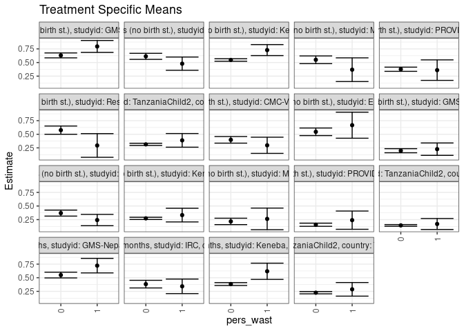

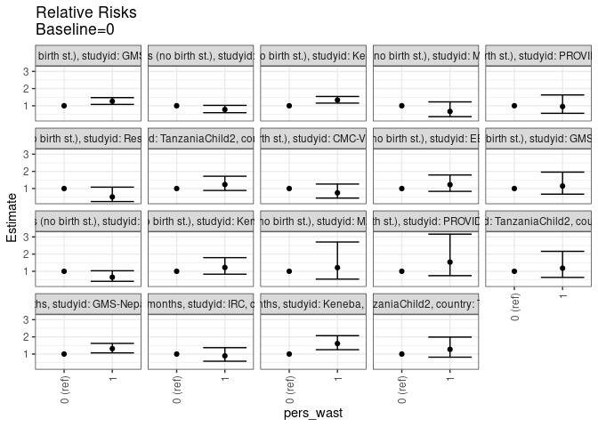

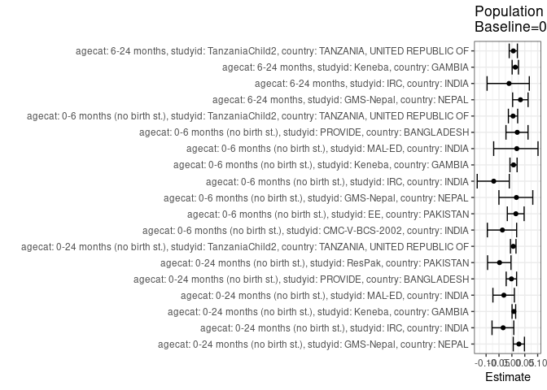

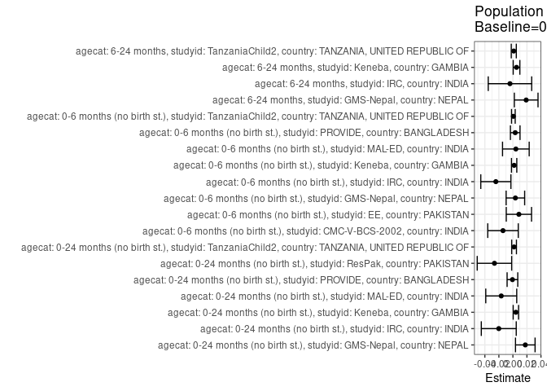

## Results Table

### Parameter: TSM

| agecat | studyid | country | intervention_level | baseline_level | estimate | ci_lower | ci_upper |
| --- | --- | --- | --- | --- | --- | --- | --- |
| 0-24 months (no birth st.) | GMS-Nepal | NEPAL | 0 | NA | 0.6307087 | 0.5853018 | 0.6761155 |
| 0-24 months (no birth st.) | GMS-Nepal | NEPAL | 1 | NA | 0.7954728 | 0.6856197 | 0.9053258 |
| 0-24 months (no birth st.) | IRC | INDIA | 0 | NA | 0.6134624 | 0.5579100 | 0.6690149 |
| 0-24 months (no birth st.) | IRC | INDIA | 1 | NA | 0.4785188 | 0.3564723 | 0.6005653 |
| 0-24 months (no birth st.) | Keneba | GAMBIA | 0 | NA | 0.5464277 | 0.5236451 | 0.5692103 |
| 0-24 months (no birth st.) | Keneba | GAMBIA | 1 | NA | 0.7283483 | 0.6274267 | 0.8292699 |
| 0-24 months (no birth st.) | MAL-ED | INDIA | 0 | NA | 0.5502646 | 0.4791714 | 0.6213577 |
| 0-24 months (no birth st.) | MAL-ED | INDIA | 1 | NA | 0.3684211 | 0.1509989 | 0.5858432 |
| 0-24 months (no birth st.) | PROVIDE | BANGLADESH | 0 | NA | 0.3766447 | 0.3380993 | 0.4151902 |
| 0-24 months (no birth st.) | PROVIDE | BANGLADESH | 1 | NA | 0.3600000 | 0.1716947 | 0.5483053 |
| 0-24 months (no birth st.) | ResPak | PAKISTAN | 0 | NA | 0.5757576 | 0.5001388 | 0.6513763 |
| 0-24 months (no birth st.) | ResPak | PAKISTAN | 1 | NA | 0.2941176 | 0.0769242 | 0.5113111 |
| 0-24 months (no birth st.) | TanzaniaChild2 | TANZANIA, UNITED REPUBLIC OF | 0 | NA | 0.3146021 | 0.2944042 | 0.3348000 |
| 0-24 months (no birth st.) | TanzaniaChild2 | TANZANIA, UNITED REPUBLIC OF | 1 | NA | 0.3881029 | 0.2625035 | 0.5137023 |
| 0-6 months (no birth st.) | CMC-V-BCS-2002 | INDIA | 0 | NA | 0.3976781 | 0.3369900 | 0.4583662 |
| 0-6 months (no birth st.) | CMC-V-BCS-2002 | INDIA | 1 | NA | 0.2972817 | 0.1488857 | 0.4456777 |
| 0-6 months (no birth st.) | EE | PAKISTAN | 0 | NA | 0.5454545 | 0.4759353 | 0.6149738 |
| 0-6 months (no birth st.) | EE | PAKISTAN | 1 | NA | 0.6666667 | 0.4275455 | 0.9057879 |
| 0-6 months (no birth st.) | GMS-Nepal | NEPAL | 0 | NA | 0.1976809 | 0.1602086 | 0.2351532 |
| 0-6 months (no birth st.) | GMS-Nepal | NEPAL | 1 | NA | 0.2265019 | 0.1129216 | 0.3400821 |
| 0-6 months (no birth st.) | IRC | INDIA | 0 | NA | 0.3697293 | 0.3144654 | 0.4249931 |
| 0-6 months (no birth st.) | IRC | INDIA | 1 | NA | 0.2420740 | 0.1384686 | 0.3456794 |
| 0-6 months (no birth st.) | Keneba | GAMBIA | 0 | NA | 0.2727714 | 0.2524506 | 0.2930923 |
| 0-6 months (no birth st.) | Keneba | GAMBIA | 1 | NA | 0.3330045 | 0.2074488 | 0.4585602 |
| 0-6 months (no birth st.) | MAL-ED | INDIA | 0 | NA | 0.2169312 | 0.1580299 | 0.2758325 |
| 0-6 months (no birth st.) | MAL-ED | INDIA | 1 | NA | 0.2631579 | 0.0646795 | 0.4616363 |
| 0-6 months (no birth st.) | PROVIDE | BANGLADESH | 0 | NA | 0.1562500 | 0.1273661 | 0.1851339 |
| 0-6 months (no birth st.) | PROVIDE | BANGLADESH | 1 | NA | 0.2400000 | 0.0724541 | 0.4075459 |
| 0-6 months (no birth st.) | TanzaniaChild2 | TANZANIA, UNITED REPUBLIC OF | 0 | NA | 0.1438390 | 0.1285959 | 0.1590821 |
| 0-6 months (no birth st.) | TanzaniaChild2 | TANZANIA, UNITED REPUBLIC OF | 1 | NA | 0.1698113 | 0.0687033 | 0.2709194 |
| 6-24 months | GMS-Nepal | NEPAL | 0 | NA | 0.5495500 | 0.4968539 | 0.6022461 |
| 6-24 months | GMS-Nepal | NEPAL | 1 | NA | 0.7224692 | 0.5888041 | 0.8561342 |
| 6-24 months | IRC | INDIA | 0 | NA | 0.3829152 | 0.3127330 | 0.4530973 |
| 6-24 months | IRC | INDIA | 1 | NA | 0.3424548 | 0.2088440 | 0.4760657 |
| 6-24 months | Keneba | GAMBIA | 0 | NA | 0.3838868 | 0.3575274 | 0.4102462 |
| 6-24 months | Keneba | GAMBIA | 1 | NA | 0.6186605 | 0.4696906 | 0.7676304 |
| 6-24 months | TanzaniaChild2 | TANZANIA, UNITED REPUBLIC OF | 0 | NA | 0.2255265 | 0.2045876 | 0.2464654 |
| 6-24 months | TanzaniaChild2 | TANZANIA, UNITED REPUBLIC OF | 1 | NA | 0.2874784 | 0.1626248 | 0.4123321 |

### Parameter: E(Y)

| agecat | studyid | country | intervention_level | baseline_level | estimate | ci_lower | ci_upper |
| --- | --- | --- | --- | --- | --- | --- | --- |
| 0-24 months (no birth st.) | GMS-Nepal | NEPAL | NA | NA | 0.6483740 | 0.6061401 | 0.6906078 |
| 0-24 months (no birth st.) | IRC | INDIA | NA | NA | 0.5933148 | 0.5424311 | 0.6441984 |
| 0-24 months (no birth st.) | Keneba | GAMBIA | NA | NA | 0.5506562 | 0.5283130 | 0.5729993 |
| 0-24 months (no birth st.) | MAL-ED | INDIA | NA | NA | 0.5336538 | 0.4656949 | 0.6016128 |
| 0-24 months (no birth st.) | PROVIDE | BANGLADESH | NA | NA | 0.3759874 | 0.3382238 | 0.4137509 |
| 0-24 months (no birth st.) | ResPak | PAKISTAN | NA | NA | 0.5494505 | 0.4769662 | 0.6219349 |
| 0-24 months (no birth st.) | TanzaniaChild2 | TANZANIA, UNITED REPUBLIC OF | NA | NA | 0.3162679 | 0.2963268 | 0.3362091 |
| 0-6 months (no birth st.) | CMC-V-BCS-2002 | INDIA | NA | NA | 0.3835616 | 0.3276935 | 0.4394298 |
| 0-6 months (no birth st.) | EE | PAKISTAN | NA | NA | 0.5539906 | 0.4870787 | 0.6209025 |
| 0-6 months (no birth st.) | GMS-Nepal | NEPAL | NA | NA | 0.2012195 | 0.1657581 | 0.2366809 |
| 0-6 months (no birth st.) | IRC | INDIA | NA | NA | 0.3454039 | 0.2961482 | 0.3946596 |
| 0-6 months (no birth st.) | Keneba | GAMBIA | NA | NA | 0.2745407 | 0.2544948 | 0.2945865 |
| 0-6 months (no birth st.) | MAL-ED | INDIA | NA | NA | 0.2211538 | 0.1646164 | 0.2776913 |
| 0-6 months (no birth st.) | PROVIDE | BANGLADESH | NA | NA | 0.1595577 | 0.1310079 | 0.1881074 |
| 0-6 months (no birth st.) | TanzaniaChild2 | TANZANIA, UNITED REPUBLIC OF | NA | NA | 0.1444976 | 0.1294204 | 0.1595748 |
| 6-24 months | GMS-Nepal | NEPAL | NA | NA | 0.5684755 | 0.5190657 | 0.6178852 |
| 6-24 months | IRC | INDIA | NA | NA | 0.3787234 | 0.3165730 | 0.4408738 |
| 6-24 months | Keneba | GAMBIA | NA | NA | 0.3890533 | 0.3630561 | 0.4150505 |
| 6-24 months | TanzaniaChild2 | TANZANIA, UNITED REPUBLIC OF | NA | NA | 0.2267846 | 0.2061497 | 0.2474195 |

### Parameter: RR

| agecat | studyid | country | intervention_level | baseline_level | estimate | ci_lower | ci_upper |
| --- | --- | --- | --- | --- | --- | --- | --- |
| 0-24 months (no birth st.) | GMS-Nepal | NEPAL | 0 | 0 | 1.0000000 | 1.0000000 | 1.000000 |
| 0-24 months (no birth st.) | GMS-Nepal | NEPAL | 1 | 0 | 1.2612365 | 1.0793307 | 1.473800 |
| 0-24 months (no birth st.) | IRC | INDIA | 0 | 0 | 1.0000000 | 1.0000000 | 1.000000 |
| 0-24 months (no birth st.) | IRC | INDIA | 1 | 0 | 0.7800295 | 0.5946050 | 1.023278 |
| 0-24 months (no birth st.) | Keneba | GAMBIA | 0 | 0 | 1.0000000 | 1.0000000 | 1.000000 |
| 0-24 months (no birth st.) | Keneba | GAMBIA | 1 | 0 | 1.3329270 | 1.1534405 | 1.540343 |
| 0-24 months (no birth st.) | MAL-ED | INDIA | 0 | 0 | 1.0000000 | 1.0000000 | 1.000000 |
| 0-24 months (no birth st.) | MAL-ED | INDIA | 1 | 0 | 0.6695344 | 0.3659365 | 1.225011 |
| 0-24 months (no birth st.) | PROVIDE | BANGLADESH | 0 | 0 | 1.0000000 | 1.0000000 | 1.000000 |
| 0-24 months (no birth st.) | PROVIDE | BANGLADESH | 1 | 0 | 0.9558079 | 0.5609149 | 1.628712 |
| 0-24 months (no birth st.) | ResPak | PAKISTAN | 0 | 0 | 1.0000000 | 1.0000000 | 1.000000 |
| 0-24 months (no birth st.) | ResPak | PAKISTAN | 1 | 0 | 0.5108359 | 0.2412906 | 1.081490 |
| 0-24 months (no birth st.) | TanzaniaChild2 | TANZANIA, UNITED REPUBLIC OF | 0 | 0 | 1.0000000 | 1.0000000 | 1.000000 |
| 0-24 months (no birth st.) | TanzaniaChild2 | TANZANIA, UNITED REPUBLIC OF | 1 | 0 | 1.2336309 | 0.8869779 | 1.715765 |
| 0-6 months (no birth st.) | CMC-V-BCS-2002 | INDIA | 0 | 0 | 1.0000000 | 1.0000000 | 1.000000 |
| 0-6 months (no birth st.) | CMC-V-BCS-2002 | INDIA | 1 | 0 | 0.7475436 | 0.4434527 | 1.260160 |
| 0-6 months (no birth st.) | EE | PAKISTAN | 0 | 0 | 1.0000000 | 1.0000000 | 1.000000 |
| 0-6 months (no birth st.) | EE | PAKISTAN | 1 | 0 | 1.2222222 | 0.8352851 | 1.788404 |
| 0-6 months (no birth st.) | GMS-Nepal | NEPAL | 0 | 0 | 1.0000000 | 1.0000000 | 1.000000 |
| 0-6 months (no birth st.) | GMS-Nepal | NEPAL | 1 | 0 | 1.1457951 | 0.6711110 | 1.956229 |
| 0-6 months (no birth st.) | IRC | INDIA | 0 | 0 | 1.0000000 | 1.0000000 | 1.000000 |
| 0-6 months (no birth st.) | IRC | INDIA | 1 | 0 | 0.6547332 | 0.4163399 | 1.029629 |
| 0-6 months (no birth st.) | Keneba | GAMBIA | 0 | 0 | 1.0000000 | 1.0000000 | 1.000000 |
| 0-6 months (no birth st.) | Keneba | GAMBIA | 1 | 0 | 1.2208189 | 0.8313501 | 1.792745 |
| 0-6 months (no birth st.) | MAL-ED | INDIA | 0 | 0 | 1.0000000 | 1.0000000 | 1.000000 |
| 0-6 months (no birth st.) | MAL-ED | INDIA | 1 | 0 | 1.2130937 | 0.5442049 | 2.704122 |
| 0-6 months (no birth st.) | PROVIDE | BANGLADESH | 0 | 0 | 1.0000000 | 1.0000000 | 1.000000 |
| 0-6 months (no birth st.) | PROVIDE | BANGLADESH | 1 | 0 | 1.5360000 | 0.7460322 | 3.162459 |
| 0-6 months (no birth st.) | TanzaniaChild2 | TANZANIA, UNITED REPUBLIC OF | 0 | 0 | 1.0000000 | 1.0000000 | 1.000000 |
| 0-6 months (no birth st.) | TanzaniaChild2 | TANZANIA, UNITED REPUBLIC OF | 1 | 0 | 1.1805654 | 0.6448240 | 2.161419 |
| 6-24 months | GMS-Nepal | NEPAL | 0 | 0 | 1.0000000 | 1.0000000 | 1.000000 |
| 6-24 months | GMS-Nepal | NEPAL | 1 | 0 | 1.3146560 | 1.0677120 | 1.618714 |
| 6-24 months | IRC | INDIA | 0 | 0 | 1.0000000 | 1.0000000 | 1.000000 |
| 6-24 months | IRC | INDIA | 1 | 0 | 0.8943360 | 0.5827104 | 1.372615 |
| 6-24 months | Keneba | GAMBIA | 0 | 0 | 1.0000000 | 1.0000000 | 1.000000 |
| 6-24 months | Keneba | GAMBIA | 1 | 0 | 1.6115701 | 1.2544732 | 2.070318 |
| 6-24 months | TanzaniaChild2 | TANZANIA, UNITED REPUBLIC OF | 0 | 0 | 1.0000000 | 1.0000000 | 1.000000 |
| 6-24 months | TanzaniaChild2 | TANZANIA, UNITED REPUBLIC OF | 1 | 0 | 1.2746992 | 0.8175345 | 1.987510 |

### Parameter: PAR

| agecat | studyid | country | intervention_level | baseline_level | estimate | ci_lower | ci_upper |
| --- | --- | --- | --- | --- | --- | --- | --- |
| 0-24 months (no birth st.) | GMS-Nepal | NEPAL | 0 | NA | 0.0176653 | 0.0037019 | 0.0316288 |
| 0-24 months (no birth st.) | IRC | INDIA | 0 | NA | -0.0201477 | -0.0450517 | 0.0047564 |
| 0-24 months (no birth st.) | Keneba | GAMBIA | 0 | NA | 0.0042284 | 0.0003994 | 0.0080574 |
| 0-24 months (no birth st.) | MAL-ED | INDIA | 0 | NA | -0.0166107 | -0.0386913 | 0.0054699 |
| 0-24 months (no birth st.) | PROVIDE | BANGLADESH | 0 | NA | -0.0006574 | -0.0082528 | 0.0069381 |
| 0-24 months (no birth st.) | ResPak | PAKISTAN | 0 | NA | -0.0263070 | -0.0508839 | -0.0017301 |
| 0-24 months (no birth st.) | TanzaniaChild2 | TANZANIA, UNITED REPUBLIC OF | 0 | NA | 0.0016658 | -0.0017173 | 0.0050489 |
| 0-6 months (no birth st.) | CMC-V-BCS-2002 | INDIA | 0 | NA | -0.0141165 | -0.0358617 | 0.0076288 |
| 0-6 months (no birth st.) | EE | PAKISTAN | 0 | NA | 0.0085361 | -0.0094907 | 0.0265629 |
| 0-6 months (no birth st.) | GMS-Nepal | NEPAL | 0 | NA | 0.0035386 | -0.0096696 | 0.0167467 |
| 0-6 months (no birth st.) | IRC | INDIA | 0 | NA | -0.0243254 | -0.0458014 | -0.0028493 |
| 0-6 months (no birth st.) | Keneba | GAMBIA | 0 | NA | 0.0017692 | -0.0020141 | 0.0055526 |
| 0-6 months (no birth st.) | MAL-ED | INDIA | 0 | NA | 0.0042226 | -0.0147759 | 0.0232212 |
| 0-6 months (no birth st.) | PROVIDE | BANGLADESH | 0 | NA | 0.0033077 | -0.0035265 | 0.0101418 |
| 0-6 months (no birth st.) | TanzaniaChild2 | TANZANIA, UNITED REPUBLIC OF | 0 | NA | 0.0006586 | -0.0019402 | 0.0032575 |
| 6-24 months | GMS-Nepal | NEPAL | 0 | NA | 0.0189255 | 0.0020497 | 0.0358012 |
| 6-24 months | IRC | INDIA | 0 | NA | -0.0041918 | -0.0351722 | 0.0267887 |
| 6-24 months | Keneba | GAMBIA | 0 | NA | 0.0051664 | 0.0004292 | 0.0099037 |
| 6-24 months | TanzaniaChild2 | TANZANIA, UNITED REPUBLIC OF | 0 | NA | 0.0012581 | -0.0023291 | 0.0048453 |

### Parameter: PAF

| agecat | studyid | country | intervention_level | baseline_level | estimate | ci_lower | ci_upper |
| --- | --- | --- | --- | --- | --- | --- | --- |
| 0-24 months (no birth st.) | GMS-Nepal | NEPAL | 0 | NA | 0.0272456 | 0.0052676 | 0.0487380 |
| 0-24 months (no birth st.) | IRC | INDIA | 0 | NA | -0.0339578 | -0.0770479 | 0.0074084 |
| 0-24 months (no birth st.) | Keneba | GAMBIA | 0 | NA | 0.0076789 | 0.0006845 | 0.0146243 |
| 0-24 months (no birth st.) | MAL-ED | INDIA | 0 | NA | -0.0311264 | -0.0736120 | 0.0096780 |
| 0-24 months (no birth st.) | PROVIDE | BANGLADESH | 0 | NA | -0.0017484 | -0.0221549 | 0.0182507 |
| 0-24 months (no birth st.) | ResPak | PAKISTAN | 0 | NA | -0.0478788 | -0.0942959 | -0.0034305 |
| 0-24 months (no birth st.) | TanzaniaChild2 | TANZANIA, UNITED REPUBLIC OF | 0 | NA | 0.0052672 | -0.0054898 | 0.0159091 |
| 0-6 months (no birth st.) | CMC-V-BCS-2002 | INDIA | 0 | NA | -0.0368037 | -0.0951357 | 0.0184213 |
| 0-6 months (no birth st.) | EE | PAKISTAN | 0 | NA | 0.0154083 | -0.0177547 | 0.0474908 |
| 0-6 months (no birth st.) | GMS-Nepal | NEPAL | 0 | NA | 0.0175857 | -0.0502772 | 0.0810636 |
| 0-6 months (no birth st.) | IRC | INDIA | 0 | NA | -0.0704258 | -0.1344645 | -0.0100021 |
| 0-6 months (no birth st.) | Keneba | GAMBIA | 0 | NA | 0.0064444 | -0.0074303 | 0.0201279 |
| 0-6 months (no birth st.) | MAL-ED | INDIA | 0 | NA | 0.0190936 | -0.0706200 | 0.1012896 |
| 0-6 months (no birth st.) | PROVIDE | BANGLADESH | 0 | NA | 0.0207302 | -0.0229464 | 0.0625419 |
| 0-6 months (no birth st.) | TanzaniaChild2 | TANZANIA, UNITED REPUBLIC OF | 0 | NA | 0.0045581 | -0.0135867 | 0.0223780 |
| 6-24 months | GMS-Nepal | NEPAL | 0 | NA | 0.0332916 | 0.0029097 | 0.0627478 |
| 6-24 months | IRC | INDIA | 0 | NA | -0.0110682 | -0.0962399 | 0.0674862 |
| 6-24 months | Keneba | GAMBIA | 0 | NA | 0.0132795 | 0.0010078 | 0.0254005 |
| 6-24 months | TanzaniaChild2 | TANZANIA, UNITED REPUBLIC OF | 0 | NA | 0.0055476 | -0.0104039 | 0.0212473 |